# CS 520 Homework: Sorting Algorithms

Tinashe M. Tapera

May 2017

In this lab report, we compare the performance of the merge sort and select sort algorithms. The scripts for these algorithms were written in Python3, and for simplicity’s sake, each one is independent from this RNotebook and wrote out the results to csv (although I would like to figure out some day how to call and run the Python script dynamically from an R environment).

Here, we compare their run time visually to discern which situations would be best for using each algorithm, if there is any difference at all.

# Statistical Comparisons

```r
stargazer(merge,title = "MergeSort Data Summary")
```

[output not shown]

```r
stargazer(select,title = "SelectSort Data Summary")
```

[output not shown]

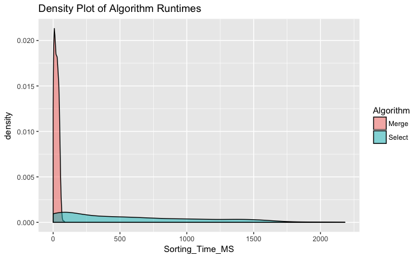

```r
ggplot(gg, aes(Sorting_Time_MS))+
  geom_density(aes(fill = Algorithm), alpha = 0.5)+
  ggtitle("Density Plot of Algorithm Runtimes")
```

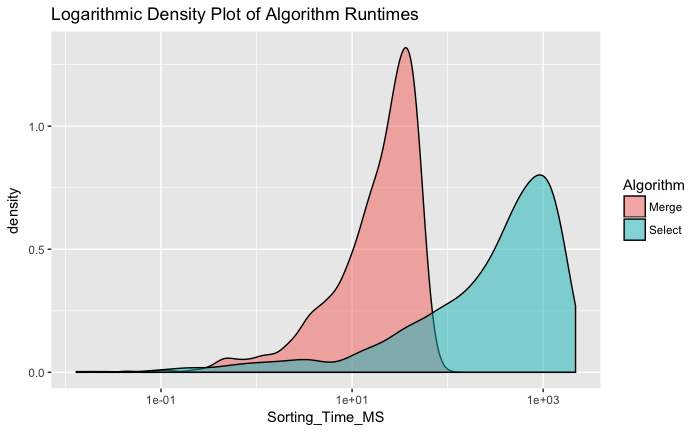

```r
ggplot(gg, aes(Sorting_Time_MS))+
  geom_density(aes(fill = Algorithm), alpha = 0.5)+
  scale_x_log10()+
  ggtitle("Logarithmic Density Plot of Algorithm Runtimes")
```

Here, we’ve had to actually plot the differences on a logarithmic scale because select sort has such a wider range. In any case, select sort will take far longer in some cases than the merge sort.

# Select Sort

Select sort is an algorithm that iterates from left to right through a list, finds a minimum value, and then swaps that minimum value with the leftmost spot. That leftmost spot is now considered “sorted”, and the algorithm then moves rightwards from there, repeating the process on the “unsorted” right half. Let’s look and see how this algorithm performs with the wide range of list lengths.

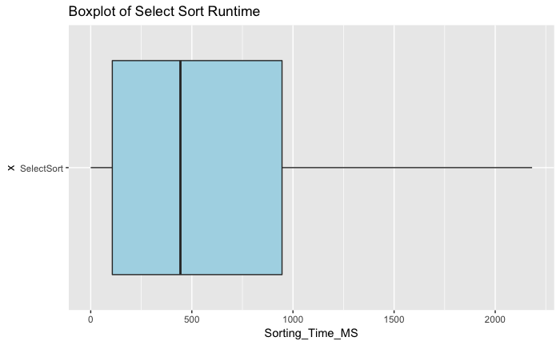

```r
ggplot(filter(gg, Algorithm == "Select"), aes("SelectSort",Sorting_Time_MS))+
  geom_boxplot(fill = "light blue")+
  ggtitle("Boxplot of Select Sort Runtime")+
  coord_flip()
```

# Merge Sort

Merge sort is a recursive solution to sorting that takes the original list and recursively breaks it down into smaller and smaller subsets of half the size; once a minimum size has been reached, the recursion sorts 2 items at a time and builds up to a completed sorted list. We can plot a similar boxplot for the merge sort algorithm.

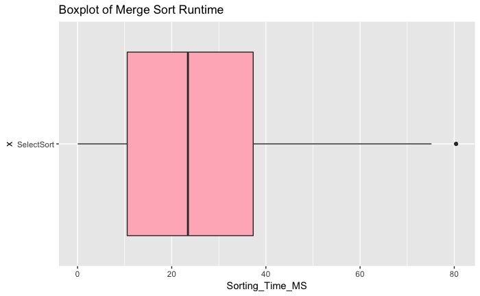

```r
ggplot(filter(gg, Algorithm == "Merge"), aes("SelectSort",Sorting_Time_MS))+
  geom_boxplot(fill = "light pink")+
  ggtitle("Boxplot of Merge Sort Runtime")+
  coord_flip()
```

Again, we have a skewed distribution here with a heavy right tail, but there is one outlier on the tail. This might indicate that it’s very unlikely that merge sort would take this long on a random list. However, also notice the difference in scales of the axis: the median is closer to the 25 millisecond mark!

# Comparison

The best way to compare these two is to use a scatter plot.

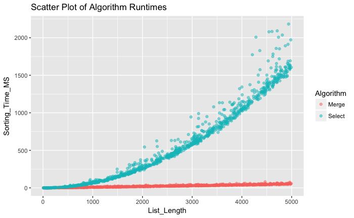

```r
ggplot(gg,aes(List_Length,Sorting_Time_MS))+
  geom_point(aes(color = Algorithm), alpha = 0.5)+
  ggtitle("Scatter Plot of Algorithm Runtimes")
```

Here’s a smoothing curve added for similar effect:

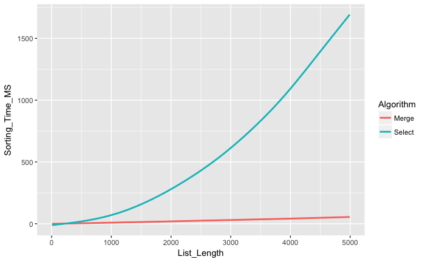

```r
ggplot(gg,aes(List_Length,Sorting_Time_MS))+
  geom_smooth(aes(color = Algorithm), alpha = 0.05, se = FALSE)
```

```r
  ggtitle("Scatter Plot of Algorithm Runtimes")
```

[output not shown]

Let’s see if this trend is the same in the area where the two are closely competing: where the list length is under 1000 members. We’ll plot that area with increasing levels of granularity.

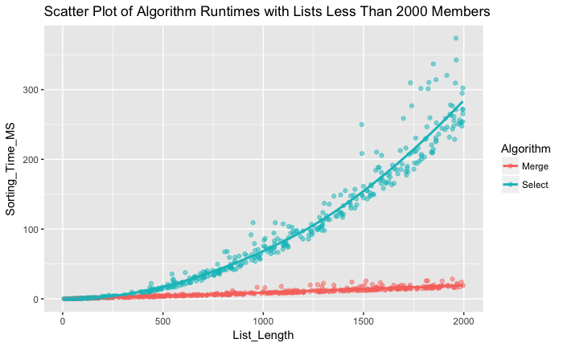

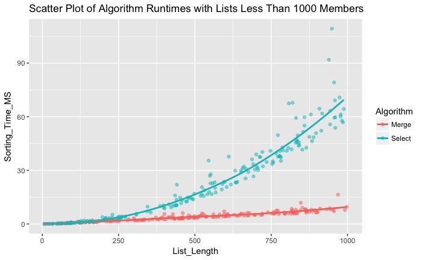

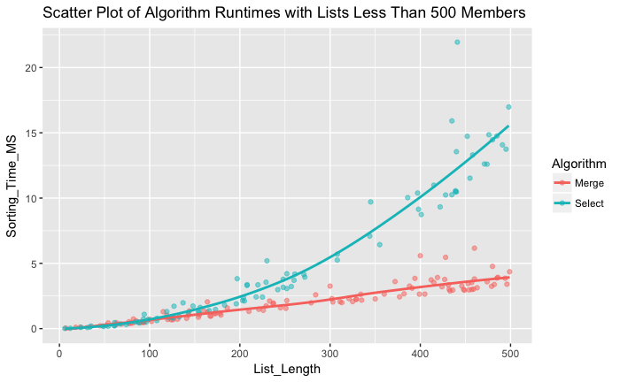

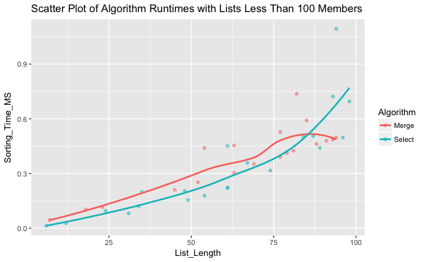

```r
zoom = c(2000,1000,500,100)
plots = list("vector",4)
par(mfrow = c(2,2))
for(i in 1:length(zoom)){
  print(ggplot(filter(gg,List_Length < zoom[i]),aes(List_Length,Sorting_Time_MS))+geom_point(aes(color = Algorithm), alpha = 0.5)+geom_smooth(aes(color = Algorithm), alpha = 0.05, se = FALSE)+ggtitle(paste0("Scatter Plot of Algorithm Runtimes with Lists Less Than ",zoom[i]," Members")))
}
```

# Conclusion

It’s clear from the visualisations that merge sort performs far better than select sort. especially when the lists are breaching the 1000 member mark. Upon closer inspection, there is a slight chance that with lists under about 75 items, the sorting time for select sort is slightly quicker. This difference, however, is minute and is surrounded by a great deal of statistical noise. It might be wise to, when implementing an astract programming language or function, use select sort when using extremely small lists, perhaps not even reaching 100. Anything beyond that, however, necessitates merge sort or better.